# Plotting with ggplot2

March 15, 2018

## Before we start

Required packages and data:

- `dplyr`: obviously
- `ggplot2`: new package
- `storms.csv`: climate data for Central America (on MOLE)

**1. Load the `dplyr` and `ggplot2` packages**

```r
library("dplyr")
library("ggplot2")
```

These should already be installed. If you see errors (you really should not by now!) you will need to install one or both of them.

**2. Read in the storms data**

Download the `storms.csv` data from MOLE. Set your working directory to the correct location and then use `read.csv` to read the data in (remember `stringsAsFactors = FALSE`), giving it the name `storms`.

## Revision

### How `ggplot2` works

## Revision: Scatter plots

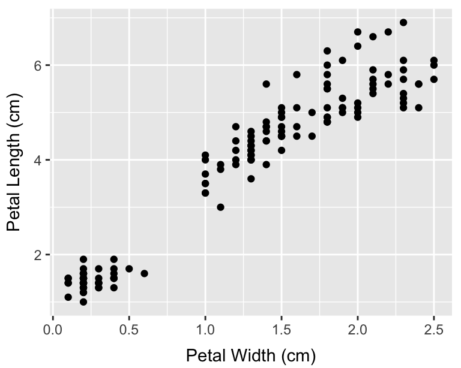

```r
ggplot(iris, aes(x = Petal.Width, y = Petal.Length)) +
  geom_point() +
  labs(x = "Petal Width (cm)", y = "Petal Length (cm)")
```

## Revision: Making things more informative

1. Customise the plot by setting arguments of a `geom_` function.
2. Add more information by including an additional aesthetic mapping.

Option 1 takes precedence over option 2. Remember that!

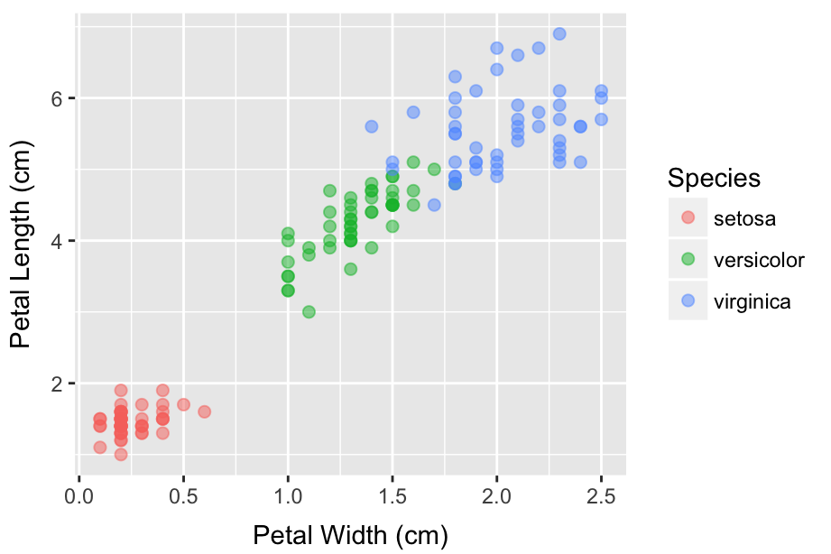

```r
ggplot(iris, aes(x = Petal.Width, y = Petal.Length, colour = Species)) +
  geom_point(size = 2, alpha = 0.5) +
  labs(x = "Petal Width (cm)", y = "Petal Length (cm)")
```

## Boxplots

### Relationships between categorical and continuous data

## What are box and whiskers plots?

Box and whisker plots summarise the distributions of a variable at different levels of a categorical variable. Here is an example:

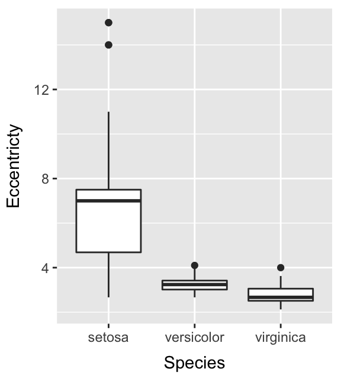

Each box-and-whisker shows us the group median (horizontal line) and the interquartile range ("boxes"). The vertical lines ("whiskers") are used to highlight the range of (most of) the rest of the data in each group. Points that may be outliers are plotted individually.

## Making box and whiskers plots

Which `geom_` function do you think we use to make a boxplot?

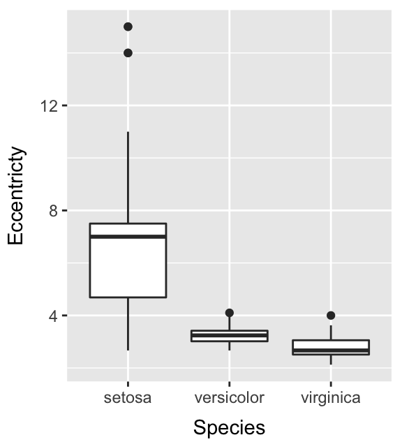

```r
ggplot(iris, aes(x = Species, y = Petal.Length/Petal.Width)) +
  geom_boxplot() +
  labs(x = "Species", y = "Eccentricty")
```

## Exercise

**Box and whiskers plots**

Working with the `storms` dataset, construct a box and whiskers plot to summarise wind speed for each type of storm.  
Extension: Try to work out how to change the background colour to white and how to change the size of the text on the graph.

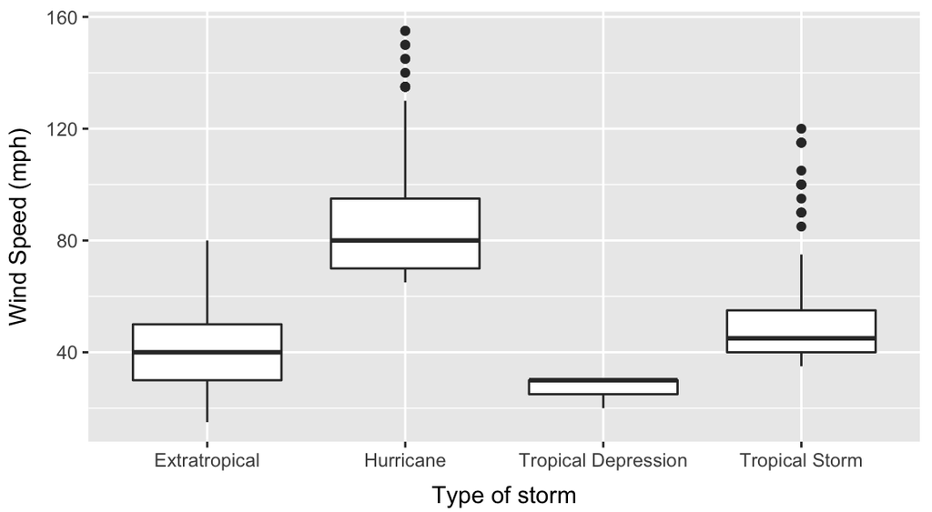

## Answer

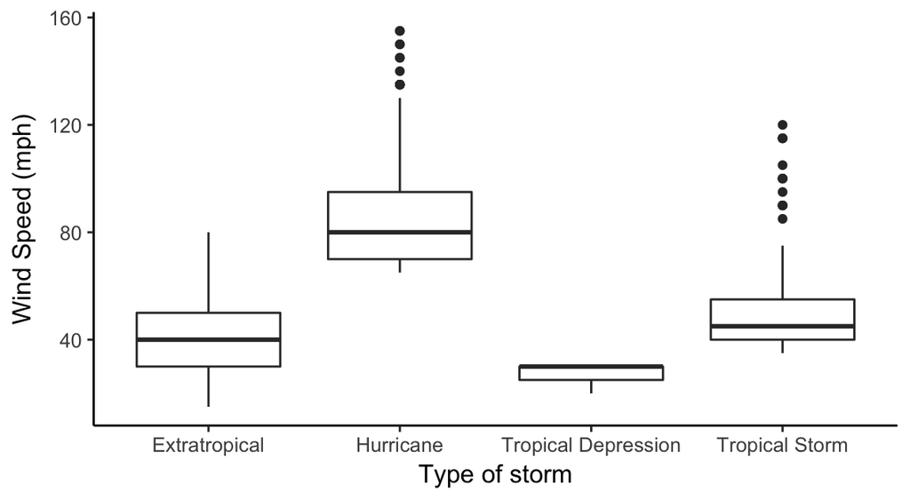

```r
ggplot(storms, aes(x = type, y = wind)) +
  geom_boxplot() +
  labs(x = "Type of storm", y = "Wind Speed (mph)") +
  theme_classic(base_size = 12)
```

## Saving plots

We can save our plots using the `ggsave` function as follows

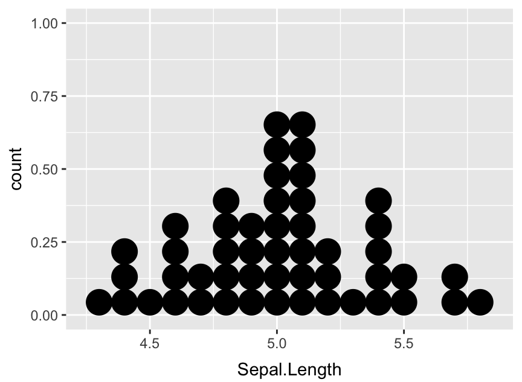

```r
setosa <- filter(iris, Species == "setosa")
ggplot(setosa, aes(x = Sepal.Length)) +
  geom_dotplot(binwidth=0.1) +
  ggsave("Sepal_dotplot.pdf", height = 4, width =4)
```

## Exercise

**Saving plots**

Use ggsave to save the box and whiskers plot that you just made. Can you work out where R has saved your plot to? (i.e. which folder on your computer)  
Can you change the dimensions of the saved plot?

## Answer

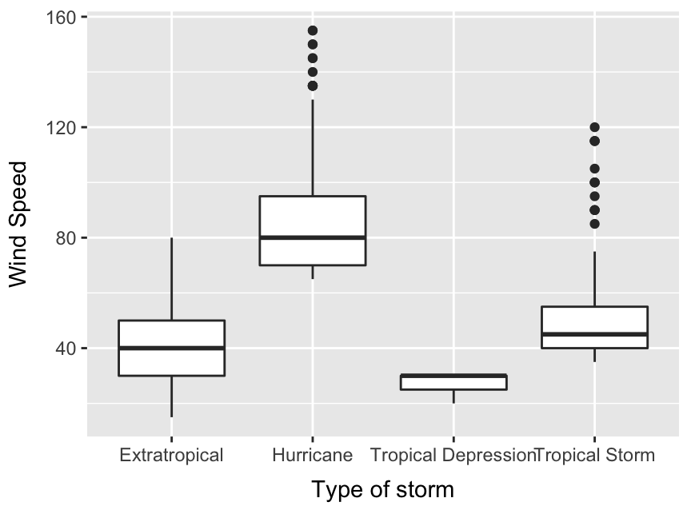

```r
ggplot(storms, aes(x = type, y = wind)) +
  geom_boxplot() +
  labs(x = "Type of storm", y = "Wind Speed") +
  ggsave("Windspeed_boxplot.pdf", height = 4, width =4)
```

## Barplots

### Summary statistics for groups

## What are bar plots?

We typically use a barplot to summarise differences in summary statistics (like the mean) among groups. We can use `geom_bar` to make barplots. When we use `geom_bar` on raw data it will simply count the number of observations:

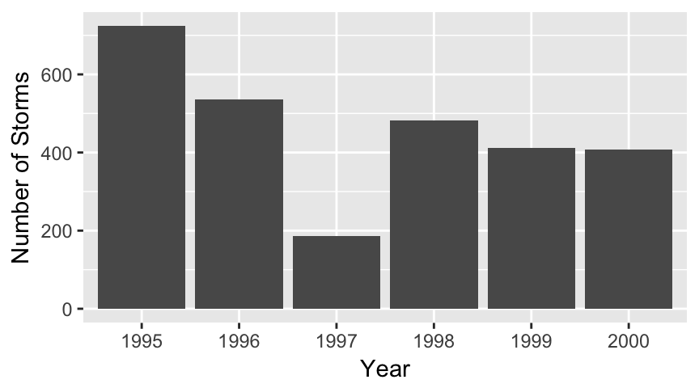

```r
ggplot(storms, aes(x = factor(year))) +
  geom_bar() +
  labs(x = "Year", y = "Number of Storms")
```

This is often not really all that useful. Usually we use a bar plot to compare **summary statistics**.

## Using bar plots to compare means

If we want to compare a summary statistic (e.g. the mean) across groups we can use the `geom_col` function instead. First we need to calculate the summary statistic. We can do this with the `group_by` and `summarise` function from the `dplyr` package. We then use the resulting data set to plot the means. For example:

[figure not shown]

```r
# step 1
pl_stats <-
  iris %>%
  group_by(Species) %>%
  summarise(mean_pl = mean(Petal.Length))
# step 2
ggplot(pl_stats, aes(x = Species, y = mean_pl)) +
  geom_col() +
  labs(y = "Mean Petal Length (cm)")
```

## Exercise

**Making a barplot of means**

Working with the `storms` dataset, construct a bar plot to summarises the mean wind speed (`wind`) associated with storms in each year (`year`). If that was too easy, see if you can change the `fill` colour of the bars to grey.

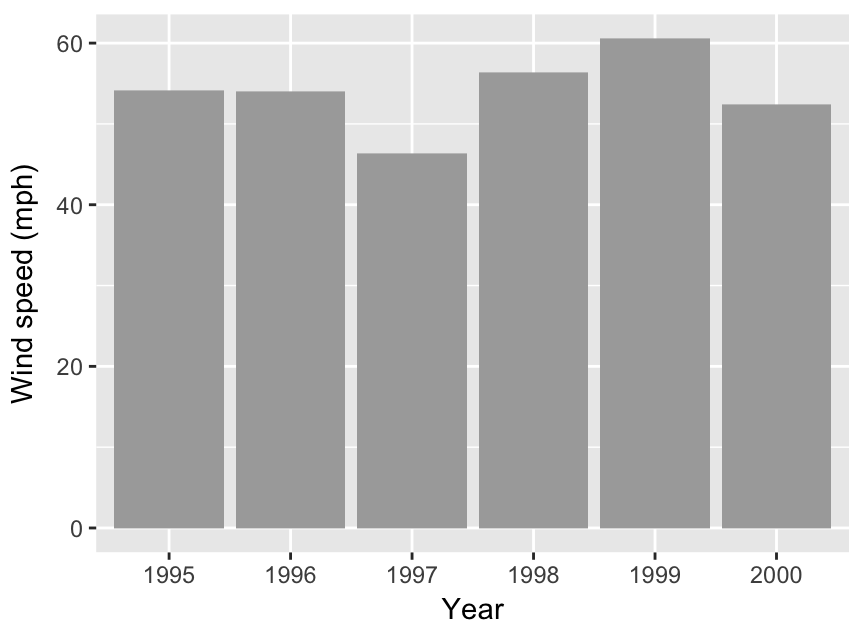

## Answer

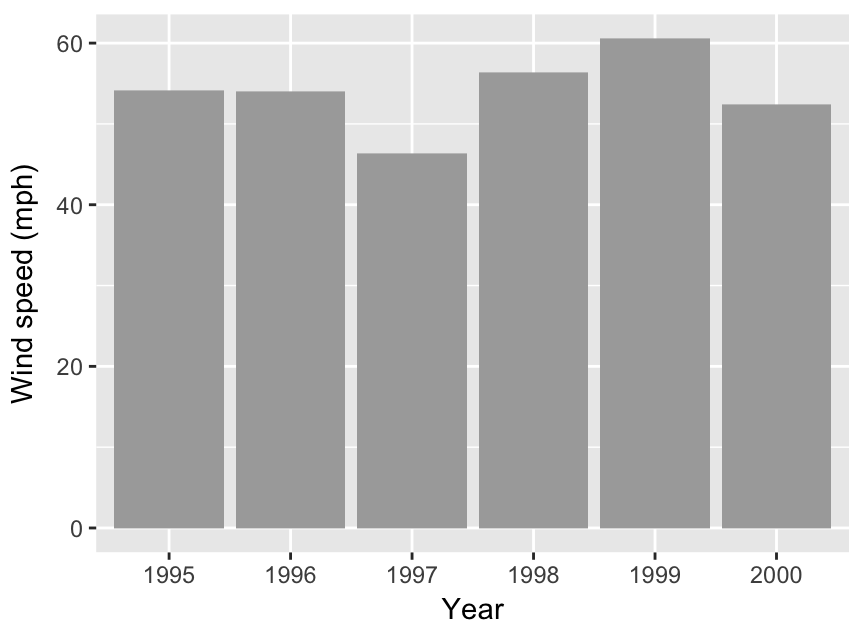

```r
# step 1 - use dplyr to calculate the means
wind.means <-
  storms %>% group_by(year) %>%
  summarise(mean= mean(wind))
# step 2 - make the plot
ggplot(wind.means, aes(x = factor(year), y = mean)) +
  geom_col(fill="darkgrey") +
  labs(x = "Year", y = "Wind speed (mph)")
```

## Adding multiple layers (1)

[figure not shown]

We can build more complex figures by adding more than one layer with the `geom_` functions. For example, we should always add an error bar of some kind to summaries of means.

The **standard error** is one option here:

\[ \text{Standard Error} = \frac{\text{Standard Deviation}}{\sqrt{\text{Sample Size}}} \]

We need to repeat the **dplyr**, but now include a calculation of the standard errors along with the means:

```r
# step 1
pl_stats <-
  iris %>%
  group_by(Species) %>%
  summarise(mean_pl = mean(Petal.Length),
            se = sd(Petal.Length) / sqrt(n())) # <- New calculation
```

## Using multiple geoms (2)

Once we have the two bits of information, we include these by adding two layers via two different `geom_` functions: `geom_col` and `geom_errorbar`. We also need to define a couple of new aesthetics…

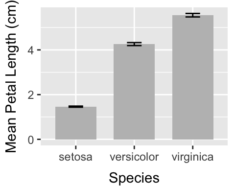

```r
# step 2
ggplot(pl_stats,
       aes(x = Species, y = mean_pl,
           ymin = mean_pl - se, ymax = mean_pl + se)) +
  geom_col(fill = "grey", width = 0.7) +
  geom_errorbar(width = 0.25) +
  labs(y = "Mean Petal Length (cm)")
```

## Exercise

**Adding error bars to your plot**

Go back to the bar plot you just made using the `storms` data set and add error bars showing the standard errors of wind speed.

## Answer

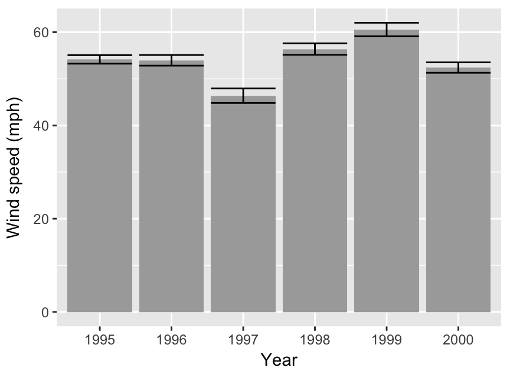

```r
# step 1 - use dplyr to calculate the means
wind.means <-
  storms %>% group_by(year) %>%
  summarise(mean = mean(wind),
            se = sd(wind)/sqrt(n()))
# step 2 - make the plot
ggplot(wind.means, aes(x = factor(year), y = mean, ymin = mean - se, ymax = mean + se)) +
  geom_col(fill="darkgrey") +
  geom_errorbar() +
  labs(x = "Year", y = "Wind speed (mph)")
```

## Exercise

**Putting it all together**

Have a look at the builtin data set on R called `ChickWeight`. Make sure you understand what variables it contains first.  
Then try to make two plots below.  
Finally think about a) what these two graphs tell you about the effectiveness of the four diets and b) what other information it might be useful to include.

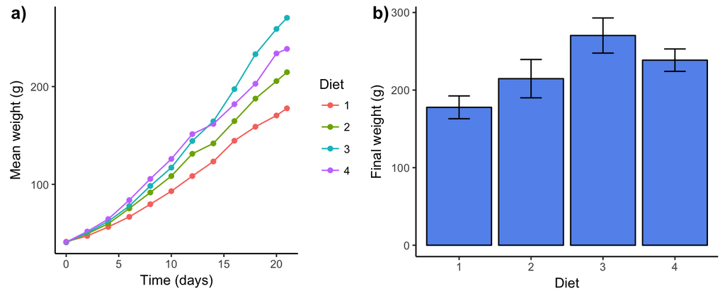

## Answer

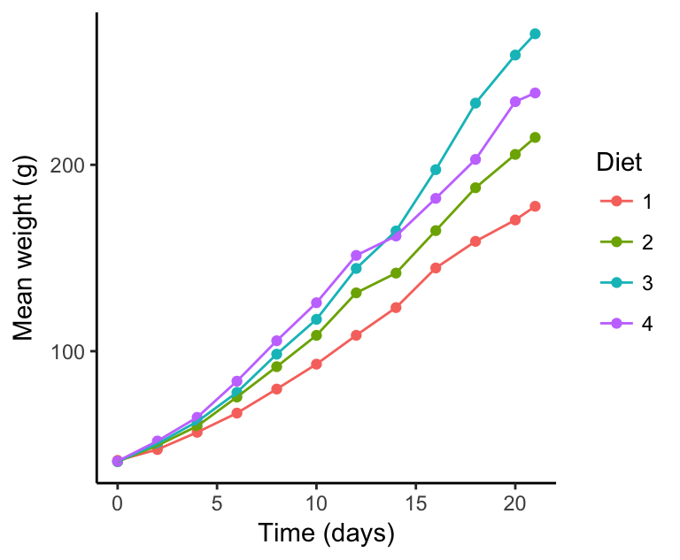

```r
## Calculate the mean and standard errors for each diet at each time point
pltdata<- group_by(ChickWeight, Time, Diet) %>%
  summarise(mn = mean(weight), se = sd(weight)/sqrt(n()))

## Plot the means over time - remembering to colour by the diet
plta <- ggplot(pltdata, aes(x=Time, y = mn, colour = Diet)) +
  geom_point() +
  geom_line() + ## Unsurprisingly the function for adding lines to our plot is geom_line
  theme_classic() +
  labs(y = "Mean weight (g)", x = "Time (days)")
plta
```

## Answer

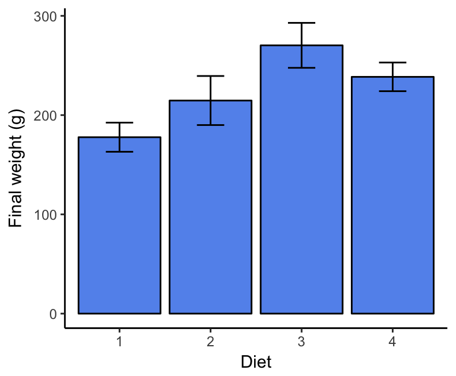

```r
## Filter the summary data to only include the final weights
pltdata2 <- ungroup(pltdata) %>%
  filter(Time==max(Time))
## Make a bar plot of the means and standard errors
pltb <- ggplot(pltdata2, aes(x=Diet, y = mn, ymin = mn-se, ymax = mn+se)) +
  geom_col(fill = 'cornflowerblue', colour = "black") +
  geom_errorbar(width = 0.3) +
  labs(y = "Final weight (g)") +
  theme_classic()
pltb
```

## Answer

We can then use the `plot_grid` function to make a panel plot containing both graphs. This function is from the `cowplot` package so you'll need to have that loaded (remember if you haven't used it before then you'll need to install it first using install.packages).

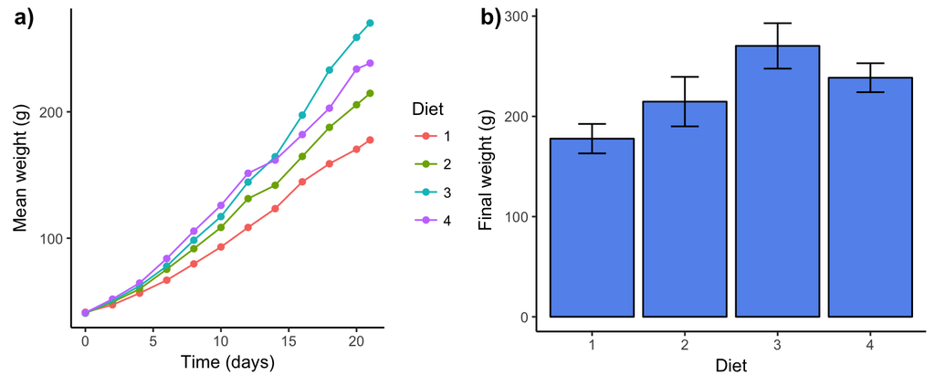

```r
library(cowplot)
plot_grid(plta, pltb, labels = c("a)", "b)"))
```

## Answer

Useful additional information could include:  
a) Sample sizes  
b) Results of a statistical test  
c) What are the different diets?

## Congratulations! We're done!

## What happens next?

1. **There is a lecture** tomorrow.
2. Course book…
3. Let me know if you have questions - bjhindle1@sheffield.ac.uk
4. Assessment after Easter